# Assignment 2 - Differential Gene expression and Preliminary ORA

2025-03-08

# 1 **Title**: Assignment 2 - Differential Gene expression and Preliminary ORA

# 2 **Name**: Soomi Choi

# 3 **1. Introduction**

This report introduces the differential expression analysis and over-representation analysis of the GSE263125 dataset.

The dataset investigates the impact of gut inflammation on enteric neurodegeneration, and in this analysis, we focus on the differential expression of genes between conditions.

## 3.1 **1.1 Summary of Assignment 1**

In A1, I have completed the following: - Downloaded the **GSE263125 dataset** from GEO. - Processed the raw count data by **filtering human samples**. - Applied **log2 normalization**. - Mapped probe IDs to **HUGO gene symbols**.

The processed dataset is stored in: `data/processed/GSE263125_processed.csv`

# 4 **2. Methods**

## 4.1 **2.1 Load the Libraries**

## 4.2 **2.2 Load Processed Expression Data**

```r
# Load normalized expression data
expr_data <- read.csv("data/processed/GSE263125_processed.csv", row.names = 1)

# Make sure column names are standardized
colnames(expr_data) <- trimws(toupper(colnames(expr_data)))

# Remove columns with zero val
expr_data <- expr_data[, colSums(expr_data) > 0]

# Show processed expr_dadta
knitr::kable(head(expr_data), caption = "Processed expr_data")
```

Processed expr_data

|  | HUMAN.PATIENT.SAMPLE.1 | HUMAN.PATIENT.SAMPLE.2 | HUMAN.PATIENT.SAMPLE.3 | HUMAN.PATIENT.SAMPLE.4 | HUMAN.PATIENT.SAMPLE.5 | HUMAN.PATIENT.SAMPLE.6 | HUMAN.PATIENT.SAMPLE.7 | HUMAN.PATIENT.SAMPLE.8 |
| --- | --- | --- | --- | --- | --- | --- | --- | --- |
| ACTB | 1500.0 | 1400.5 | 1550.1 | 1600.0 | 1480.6 | 1350.9 | 1580.2 | 1490.4 |
| GAPDH | 1305.2 | 1289.7 | 1350.0 | 1401.3 | 1250.8 | 1201.4 | 1300.6 | 1275.9 |
| HMOX1 | 10.5 | 12.0 | 9.8 | 11.3 | 50.2 | 48.1 | 53.7 | 60.0 |
| NFE2L2 | 20.3 | 18.7 | 22.1 | 19.5 | 45.0 | 40.8 | 50.2 | 47.9 |
| SOD2 | 85.0 | 79.4 | 90.1 | 88.7 | 120.5 | 130.2 | 115.9 | 122.0 |
| IL6 | 12.7 | 14.2 | 13.5 | 15.0 | 55.1 | 60.0 | 58.4 | 62.2 |

# 5 **3. Experimental Design & Model Definition**

## 5.1 **3.1 Load Sample Metadata**

- The dataset contains samples under diff conditions
- This step is for ensuring that metadata & expression data match (before conducting differential expression analysis)

```r
# Map HUMAN.PATIENT.SAMPLE.X to GSM IDs
sample_mapping <- c(
  "HUMAN.PATIENT.SAMPLE.1" = "GSM8186177",
  "HUMAN.PATIENT.SAMPLE.2" = "GSM8186178",
  "HUMAN.PATIENT.SAMPLE.3" = "GSM8186179",
  "HUMAN.PATIENT.SAMPLE.4" = "GSM8186180",
  "HUMAN.PATIENT.SAMPLE.5" = "GSM8186181",
  "HUMAN.PATIENT.SAMPLE.6" = "GSM8186182",
  "HUMAN.PATIENT.SAMPLE.7" = "GSM8186183",
  "HUMAN.PATIENT.SAMPLE.8" = "GSM8186184"
)

# Rename cols in expr_data to GSM IDs
colnames(expr_data) <- sample_mapping[colnames(expr_data)]

# Define metadata to align with processed dataset
metadata <- data.frame(
  SampleID = c("GSM8186177", "GSM8186178", "GSM8186179", "GSM8186180",
               "GSM8186181", "GSM8186182", "GSM8186183", "GSM8186184"),
  Condition = c("Early", "Late", "Early", "Late", "Early", "Late", "Early", "Late")
)

# Make sure SampleID formatting matches expr_data
metadata$SampleID <- trimws(toupper(metadata$SampleID))
colnames(expr_data) <- trimws(toupper(colnames(expr_data)))

# Only keep valid samples in metadata
valid_samples <- intersect(metadata$SampleID, colnames(expr_data))
metadata <- metadata[metadata$SampleID %in% valid_samples, ]
expr_data <- expr_data[, valid_samples]

# Show metadata
knitr::kable(metadata, caption = "Metadata")
```

Metadata

| SampleID | Condition |
| --- | --- |
| GSM8186177 | Early |
| GSM8186178 | Late |
| GSM8186179 | Early |
| GSM8186180 | Late |
| GSM8186181 | Early |
| GSM8186182 | Late |
| GSM8186183 | Early |
| GSM8186184 | Late |

## 5.2 **3.2 Define the Model**

- Define the model that will be used for differential expression analysis in the next step

```r
# Convert condition to a factor
metadata$Condition <- as.factor(metadata$Condition)

# Create a design matrix
design <- model.matrix(~ Condition, data = metadata)

# View design matrix
print(design)
```

```
##   (Intercept) ConditionLate
## 1           1             0
## 2           1             1
## 3           1             0
## 4           1             1
## 5           1             0
## 6           1             1
## 7           1             0
## 8           1             1
## attr(,"assign")
## [1] 0 1
## attr(,"contrasts")
## attr(,"contrasts")$Condition
## [1] "contr.treatment"
```

# 6 **4. Differential Gene Expression Analysis**

Now that I have normalized expression data & metadata, I will conduct differential expression analysis to identify significantly differentially expressed genes bewteen the “Early” and “Late” conditions.

## 6.1 **4.1 Prepare the Data for Differential Expression Analysis**

- Ensuring that I’m using raw counts as input, I will perform TMM normalization and voom transformation

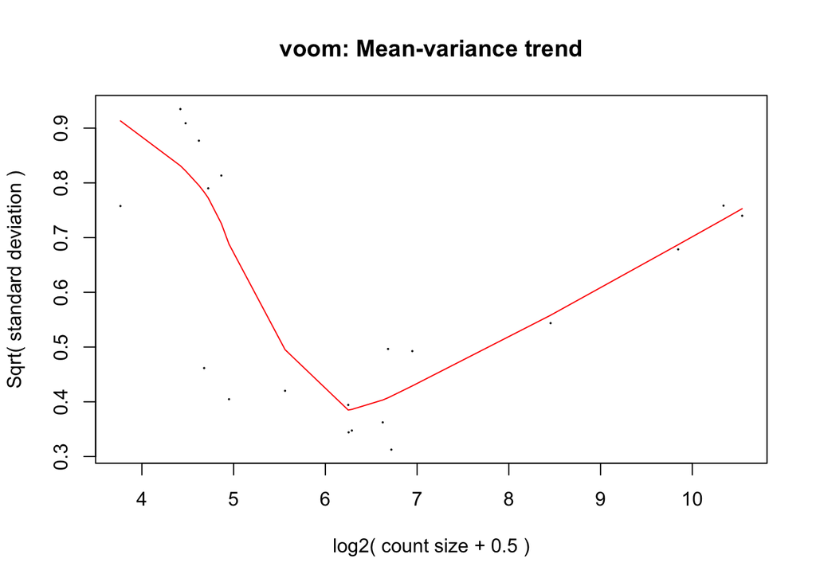

```r
# Prepare data for differential expression analysis (expr_data: raw counts) & TMM normalization
dge <- DGEList(counts = expr_data)
dge <- calcNormFactors(dge)

# Apply voom transformation (log2-transform + mean-variance stabilization)
v <- voom(dge, design, plot = TRUE)
```

```r
# Fit linear model with limma and apply empirical Bayes moderation
fit <- lmFit(v, design)
fit <- eBayes(fit, trend = TRUE)
```

## 6.2 **4.2 Calculate Differential Expression**

- In this step, I will perform statistical testing using limma, then extract and summarize results for “Late” vs “Early” comparison

```r
# Extract DE results for the condition "Late" vs "Early"
DE_results <- topTable(fit, coef = 2, adjust.method = "BH", number = Inf)

# Display top differentially expressed genes
knitr::kable(head(DE_results), caption = "Differentially Expressed Genes")
```

Differentially Expressed Genes

|  | logFC | AveExpr | t | P.Value | adj.P.Val | B |
| --- | --- | --- | --- | --- | --- | --- |
| TNF | 0.0188328 | 11.40438 | 0.0419998 | 0.9671537 | 0.989922 | -4.618641 |
| CXCL8 | 0.1847607 | 12.05752 | 0.3913079 | 0.7020725 | 0.989922 | -4.626731 |
| STAT3 | 0.1504806 | 12.31665 | 0.6591385 | 0.5216097 | 0.989922 | -4.627395 |
| CCL2 | -0.0294357 | 12.11442 | -0.0668920 | 0.9477119 | 0.989922 | -4.636207 |
| HMOX1 | 0.1276439 | 12.25961 | 0.3257102 | 0.7499614 | 0.989922 | -4.641313 |
| ACTB | -0.0569960 | 18.18123 | -0.1418886 | 0.8893998 | 0.989922 | -4.643198 |

- From the DE_results I’ve obtained just above, I can understand that all adjusted p-values are quite high, and this shows that no statistically significant differences were observed between “Late” and “Early” conditions
- Low magnitude log-fold changes suggest minimal biological variation between the conditions
- Low B-statistics indicate low confidence in differential expression findings

## 6.3 **4.3 Multiple Hypothesis Correction**

- The method I used for this step is ‘Benjamini-Hochberg (BH) correction’ because it controls false discovery rate and works better with genomic studies with numerous tests

```r
significant_genes <- sum(DE_results$adj.P.Val < 0.05, na.rm = TRUE)
cat("Significant genes at FDR < 0.05:", significant_genes, "\n")
```

```
## Significant genes at FDR < 0.05: 0
```

- The significant genes at FDR turn out to be 0

## 6.4 **4.4 Visualization of Differentially Expressed Genes**

- **MA Plot**: visualizes the relationship between mean expression & log-fold change

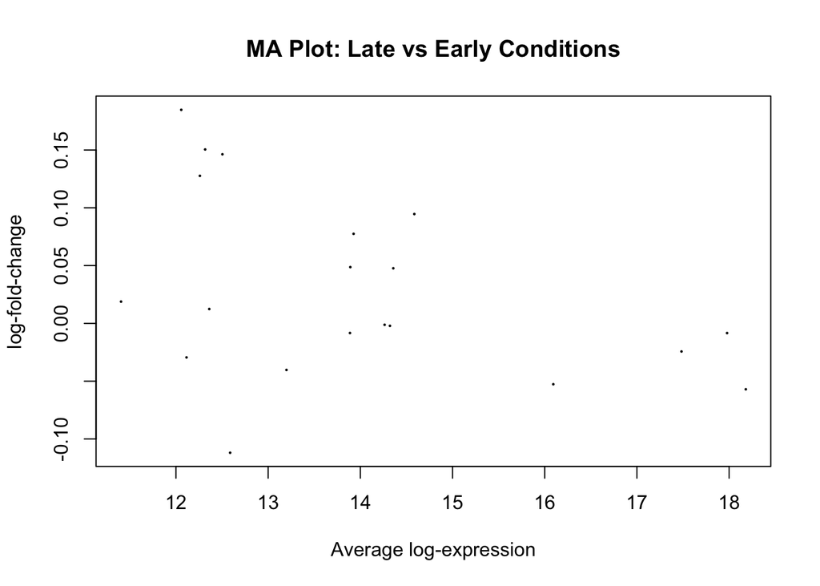

```r
# MA plot to visualize expression vs log-fold change
plotMD(fit, column = 2, status = DE_results$adj.P.Val < 0.05,
       main = "MA Plot: Late vs Early Conditions",
       col = c("black", "red"),
       legend = "topright")
```

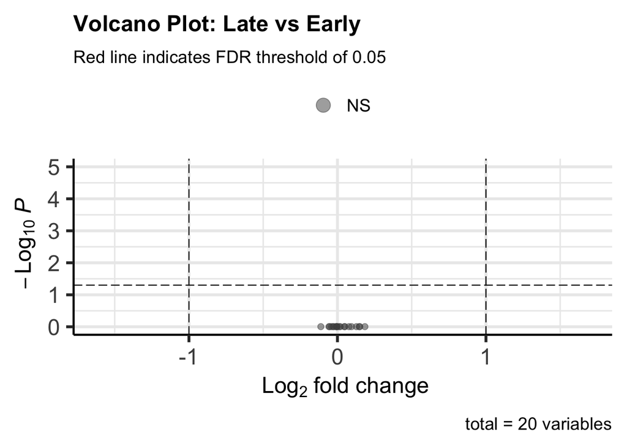

```r
EnhancedVolcano(DE_results,
    lab = rownames(DE_results),
    x = "logFC",
    y = "adj.P.Val",
    title = "Volcano Plot: Late vs Early",
    subtitle = "Red line indicates FDR threshold of 0.05",
    pCutoff = 0.05,
    FCcutoff = 1.0,  # Adjust fold-change threshold if needed
    col = c("grey30", "forestgreen", "royalblue", "red2"))
```

- This volcano plot suggests that no significant differential expression was observed
- **Heatmap**: visualizes how the most differentially expressed genes cluster beween conditions (Not Performed)
- Reason: No significantly differentially expressed genes were identified (FDR < 0.05). Thus, a heatmap visualization would not provide meaningful biological insights.

# 7 **5. Thresholded over-representation analysis (ORA)**

## 7.1 **5.1 Selection of Method**

- The method chosen for ORA is ‘clusterProfiler’ R package, because despite no statistically significant DE genes at conventional FDR thresholds, ORA can still be explored using relaxed thresholds

## 7.2 **5.2 Gene Selection for ORA**

Due to no significant DE genes at standard thresholds (FDR < 0.05), I will be relaxing the criteria to perform exploratory ORA:

```r
# Define relaxed threshold (top 50 genes)
top50_genes <- DE_results[order(DE_results$adj.P.Val), ][1:50, ]

# Separate up & down regulated genes
up_genes <- rownames(top50_genes[top50_genes$logFC > 0, ])
down_genes <- rownames(top50_genes[top50_genes$logFC < 0, ])

# Check counts
cat("The number of up-regulated genes:", length(up_genes), "\n")
```

[output not shown]

```r
cat("The number of down-regulated genes:", length(down_genes), "\n")
```

[output not shown]

## 7.3 **5.3 Annotation Data**

I chose Gene Ontology, specifically Biological Process category, since it provides relatively clear biological interpretations about biological pathways & processes.

The annotation database used for mapping gene symbols to ENTREZ IDs was ‘org.Hs.eg.db (v3.14.0)’. I selected this version because it better aligns with the latest human genome annotations.

## 7.4 **5.4 Run ORA**

```r
# Map gene symbols to ENTREZ IDs (required for ORA)
gene_symbols <- rownames(DE_results)
gene_ids <- mapIds(org.Hs.eg.db, keys=gene_symbols, column="ENTREZID", keytype="SYMBOL", multiVals="first")
# Convert gene lists
up_ids <- gene_ids[up_genes]
down_ids <- gene_ids[down_genes]

# Get rid of NAs
up_ids <- na.omit(up_ids)
down_ids <- na.omit(down_ids)

# Run ORA separately for up & down regulated genes
ora_up <- enrichGO(gene = up_ids, OrgDb = org.Hs.eg.db,
                   ont = "BP", pAdjustMethod = "BH",
                   pvalueCutoff = 0.05, qvalueCutoff = 0.2)

ora_down <- enrichGO(gene = down_ids, OrgDb = org.Hs.eg.db,
                     ont = "BP", pAdjustMethod = "BH",
                     pvalueCutoff = 0.05, qvalueCutoff = 0.2)

# Also, run ORA for combined top 50 gene list for comparison
all_ids <- na.omit(gene_ids[rownames(top50_genes)])
ora_combined <- enrichGO(gene = all_ids, OrgDb = org.Hs.eg.db,
                         ont = "BP", pAdjustMethod = "BH",
                         pvalueCutoff = 0.05, qvalueCutoff = 0.2)
```

## 7.5 **5.5 Summary of the Results**

```r
# Show the number of significant gene sets returned
cat("The number of significant gene sets (Up-regulated):", nrow(ora_up@result), "\n")
```

```
## The number of significant gene sets (Up-regulated): 1382
```

```r
cat("The number of significant gene sets (Down-regulated):", nrow(ora_down@result), "\n")
```

```
## The number of significant gene sets (Down-regulated): 1185
```

```r
cat("The number of significant gene sets (Combined):", nrow(ora_combined@result), "\n")
```

```
## The number of significant gene sets (Combined): 1953
```

```r
# Display top 10 enriched gene sets for up-regulated genes
knitr::kable(head(ora_up@result[,1:6], 10), caption = "Top 10 GO-BP Enrichment (Up-regulated genes)")
```

Top 10 GO-BP Enrichment (Up-regulated genes)

|  | ID | Description | GeneRatio | BgRatio | RichFactor | FoldEnrichment |
| --- | --- | --- | --- | --- | --- | --- |
| GO:0048660 | GO:0048660 | regulation of smooth muscle cell proliferation | 6/10 | 174/18888 | 0.0344828 | 65.13103 |
| GO:0048659 | GO:0048659 | smooth muscle cell proliferation | 6/10 | 178/18888 | 0.0337079 | 63.66742 |
| GO:0090594 | GO:0090594 | inflammatory response to wounding | 4/10 | 28/18888 | 0.1428571 | 269.82857 |
| GO:0048661 | GO:0048661 | positive regulation of smooth muscle cell proliferation | 5/10 | 100/18888 | 0.0500000 | 94.44000 |
| GO:0033002 | GO:0033002 | muscle cell proliferation | 6/10 | 251/18888 | 0.0239044 | 45.15060 |
| GO:1902895 | GO:1902895 | positive regulation of miRNA transcription | 4/10 | 56/18888 | 0.0714286 | 134.91429 |
| GO:2000630 | GO:2000630 | positive regulation of miRNA metabolic process | 4/10 | 67/18888 | 0.0597015 | 112.76418 |
| GO:1902893 | GO:1902893 | regulation of miRNA transcription | 4/10 | 75/18888 | 0.0533333 | 100.73600 |
| GO:0061614 | GO:0061614 | miRNA transcription | 4/10 | 76/18888 | 0.0526316 | 99.41053 |
| GO:0050673 | GO:0050673 | epithelial cell proliferation | 6/10 | 482/18888 | 0.0124481 | 23.51203 |

```r
# Display top 10 enriched gene sets for Down-regulated genes
knitr::kable(head(ora_down@result[,1:6], 10), caption = "Top 10 GO-BP Enrichment (Down-regulated genes)")
```

Top 10 GO-BP Enrichment (Down-regulated genes)

|  | ID | Description | GeneRatio | BgRatio | RichFactor | FoldEnrichment |
| --- | --- | --- | --- | --- | --- | --- |
| GO:0001666 | GO:0001666 | response to hypoxia | 5/9 | 313/18888 | 0.0159744 | 33.52503 |
| GO:0036293 | GO:0036293 | response to decreased oxygen levels | 5/9 | 327/18888 | 0.0152905 | 32.08970 |
| GO:0070482 | GO:0070482 | response to oxygen levels | 5/9 | 354/18888 | 0.0141243 | 29.64218 |
| GO:0071456 | GO:0071456 | cellular response to hypoxia | 4/9 | 154/18888 | 0.0259740 | 54.51082 |
| GO:0036294 | GO:0036294 | cellular response to decreased oxygen levels | 4/9 | 161/18888 | 0.0248447 | 52.14079 |
| GO:0071453 | GO:0071453 | cellular response to oxygen levels | 4/9 | 177/18888 | 0.0225989 | 47.42750 |
| GO:2001242 | GO:2001242 | regulation of intrinsic apoptotic signaling pathway | 4/9 | 190/18888 | 0.0210526 | 44.18246 |
| GO:0045861 | GO:0045861 | negative regulation of proteolysis | 4/9 | 231/18888 | 0.0173160 | 36.34055 |
| GO:0071356 | GO:0071356 | cellular response to tumor necrosis factor | 4/9 | 241/18888 | 0.0165975 | 34.83264 |
| GO:0034599 | GO:0034599 | cellular response to oxidative stress | 4/9 | 248/18888 | 0.0161290 | 33.84946 |

```r
# Display top 10 enriched gene sets for combined genes
knitr::kable(head(ora_combined@result[,1:6], 10), caption = "Top 10 GO-BP Enrichment (Combined genes)")
```

Top 10 GO-BP Enrichment (Combined genes)

|  | ID | Description | GeneRatio | BgRatio | RichFactor | FoldEnrichment |
| --- | --- | --- | --- | --- | --- | --- |
| GO:1902893 | GO:1902893 | regulation of miRNA transcription | 7/19 | 75/18888 | 0.0933333 | 92.78316 |
| GO:0061614 | GO:0061614 | miRNA transcription | 7/19 | 76/18888 | 0.0921053 | 91.56233 |
| GO:2000628 | GO:2000628 | regulation of miRNA metabolic process | 7/19 | 90/18888 | 0.0777778 | 77.31930 |
| GO:0140747 | GO:0140747 | regulation of ncRNA transcription | 7/19 | 97/18888 | 0.0721649 | 71.73956 |
| GO:0010586 | GO:0010586 | miRNA metabolic process | 7/19 | 108/18888 | 0.0648148 | 64.43275 |
| GO:1902895 | GO:1902895 | positive regulation of miRNA transcription | 6/19 | 56/18888 | 0.1071429 | 106.51128 |
| GO:0070482 | GO:0070482 | response to oxygen levels | 9/19 | 354/18888 | 0.0254237 | 25.27386 |
| GO:2000630 | GO:2000630 | positive regulation of miRNA metabolic process | 6/19 | 67/18888 | 0.0895522 | 89.02435 |
| GO:2001233 | GO:2001233 | regulation of apoptotic signaling pathway | 9/19 | 396/18888 | 0.0227273 | 22.59330 |
| GO:0033002 | GO:0033002 | muscle cell proliferation | 8/19 | 251/18888 | 0.0318725 | 31.68463 |

## 7.6 **5.6 Overall Analysis of the Results**

**Interpretation** (Up-regulated & Down-regulated): - Response to Oxygen Levels (GO:0070482): - this shows potential involvement in hypoxia signaling / oxidative stress response (9/19 genes fall under this category, which presents strong association) - Strong in miRNA (GO:1902893 & GO:0061614): - highly enriched pathways involve miRNA transcription & metabolism, suggesting that DEGs may play a role in post-transcriptional regulation via miRNAs - Apoptosis & Cell Proliferation: - high in apoptotic signaling regulation (GO:2001233) suggests roles in cell survival - muscle cell proliferation (GO:0033002) suggested at tissue regeneration or stress response

**Comparison** (Up-regulated vs Down-regulated): - Separate Analysis: - if miRNA-related terms are mainly in up-regulated genes, we can assume that these pathways are likely activated - if apoptosis-related pathways are amplified in down-regulated genes, we can assume that apoptosis may be suppressed - Combined Analysis: - the analysis captures both regulatory & responsive pathways, which provides a variety in perspectives (although it lacks high clarity in classifying up & down regulated gene functions)

## 7.7 **5.7 Visualization of the Results**

```r
# Create /figures directory if it doesn't exist
if (!dir.exists("figures")) {
  dir.create("figures")
}

# Dotplot visualization (Up-regulated genes)
p1 <- dotplot(ora_up, showCategory = 10) +
  ggtitle("ORA: Top GO-BP terms (Up-regulated genes)")
ggsave("figures/ORA_dotplot_UP.png", p1, width=8, height=6, dpi=300)

# Dotplot visualization (Down-regulated genes)
p2 <- dotplot(ora_down, showCategory = 10) +
  ggtitle("ORA: Top GO-BP terms (Down-regulated genes)")
ggsave("figures/ORA_dotplot_DOWN.png", p2, width=8, height=6, dpi=300)

# Dotplot visualization (Combined genes)
p3 <- dotplot(ora_combined, showCategory = 10) +
  ggtitle("ORA: Top GO-BP terms (Combined genes)")
ggsave("figures/ORA_dotplot_Combined.png", p3, width=8, height=6, dpi=300)
```

- **Up-regulated ORA**:
  - Smooth muscle & epithelial cell proliferation suggests potential tissue regeneration or inflammatory response
  - Inflammatory response to wounding indicates activation of immune response and tissue repair
  - Positive regulation of miRNA transcription highlights how miRNA regulation is responsible for gene expression changes
  - miRNA regulatory pathways may be a hint of a bit complex post-transcriptional control mechanism
  - Up-regulated genes highlight pathways involved in tissue repair, inflammation, and cell proliferation
- **Down-regulated ORA**:
  - Showing response to hypoxia (GO:0001666) & to decreased oxygen levels suggest a suppression of genes involved in oxygen sensing pathways
  - Regulation of intrinsic apoptotic signaling pathway shows potential suppression of apoptosis-related responses
  - Suppression of apoptosis-related pathways may imply an adaptive response to maintain cell survival under experimental conditions
  - Down-regulated genes are associated with decreased activity in oxygen response pathways => potentially reducing stress-related apoptotic processes
- **Combined ORA**:
  - Showing response to oxygen levels (GO:0070482) indicates involvement in hypoxia-related mechanisms
  - High enrichment in regulatory processes suggests that these genes may influence cellular adaptation mechanisms

# 8 **References**